Universidad El Bosque

Diseño de Experimentos

Sesión 2 de 2 · 90 min

# Diseños anidados

Estimar, revisar y extender: los componentes de varianza, sus intervalos, el diagnóstico, las m etapas, el anidado y cruzado a la vez y la fuga por agrupación

Componentes de varianzaCorrelación intraclaseIntervalosDiagnósticom etapasRestringido y no restringidoFuga por agrupación

**Javier Mauricio Sierra**

Universidad El Bosque

Diseño de Experimentos

Capítulo 9 · Diseños anidados

Estimar los componentes de varianza

Intervalos para los componentes

Diagnóstico del modelo anidado

El anidado de m etapas

Anidado y cruzado a la vez

Ciencia de datos: la fuga por agrupación

Cierre y práctica

Hoja de ruta

## Lo que vamos a construir hoy

Objetivo de la sesión

Estimar dónde vive la variación de un diseño anidado y con qué incertidumbre, revisar el modelo, extenderlo a m etapas y a factores cruzados y anidados a la vez, y reconocer el mismo error en la validación cruzada con datos agrupados.

Componentes de varianzaCorrelación intraclaseIntervalosDiagnósticom etapasRestringido y no restringidoFuga por agrupación

2 / 39

Universidad El Bosque

Diseño de Experimentos

Capítulo 9 · Diseños anidados

Estimar los componentes de varianza

Intervalos para los componentes

Diagnóstico del modelo anidado

El anidado de m etapas

Anidado y cruzado a la vez

Ciencia de datos: la fuga por agrupación

Cierre y práctica

01

## Estimar los componentes de varianza

La pregunta que motiva un anidado: ¿dónde está la variación?

Leer en el material: 9.6 Estimar los componentes de varianza

3 / 39

Estimar los componentes de varianza

## Un componente de varianza se estima igualando cada cuadrado medio a su esperanza

$$MS_{B(A)} = \hat\sigma^2 + n\,\hat\sigma^2_\beta, \qquad MS_E = \hat\sigma^2 \;\Longrightarrow\; \hat\sigma^2_\beta = \frac{MS_{B(A)} - MS_E}{n}$$

Dato · ejemplo 14.1

\(\hat\sigma^2 = 2.6389\) y \(\hat\sigma^2_\beta = (7.7685 - 2.6389)/3 = 1.7099\)

**Interpretación.** Cuando un factor es aleatorio no se estima su efecto, sino su varianza. Aquí el sistema es triangular y se resuelve de abajo arriba.

Fuente: Montgomery (2017), ecs. 14.10 y 14.11, Tabla 14.6; código R del módulo 9.6

Capítulo 9 · Diseños anidadosDiseño de Experimentos · UnBosque4 / 39

Estimar los componentes de varianza

## El 39.3 % de la variación aleatoria de la pureza vive entre barriles del mismo proveedor

Componentes de varianza (método del ANOVA)

```
s2_e <- ms[["E"]]
s2_b <- (ms[["B"]] - s2_e) / pur_n
round(c(sigma2 = s2_e, sigma2_beta = s2_b,
        total = s2_e + s2_b,
        ICC = s2_b / (s2_e + s2_b)), 6)
#>      sigma2 sigma2_beta       total         ICC
#>    2.638889    1.709877    4.348765    0.393187
```

- \(1.7099 / (1.7099 + 2.6389) = 0.3932\)
- El resto, el 60.7 %, es error de medición dentro del barril
- Esa fracción es la **correlación intraclase**: la de dos determinaciones del mismo barril

**Interpretación.** Una vez descontado el proveedor, que aquí es fijo, cuatro de cada diez partes de la variación son de barril a barril.

Fuente: Montgomery (2017), ejemplo 14.1; código R del módulo 9.6

Capítulo 9 · Diseños anidadosDiseño de Experimentos · UnBosque5 / 39

Estimar los componentes de varianza

## El estimador es insesgado y, aun así, puede salir negativo

\(E\!\left[\dfrac{MS_{B(A)} - MS_E}{n}\right] = \dfrac{(\sigma^2 + n\sigma^2_\beta) - \sigma^2}{n} = \sigma^2_\beta\): insesgado, sin suponer normalidad

Pero es una **diferencia** de dos cuadrados medios: con \(\sigma^2_\beta\) pequeño, la diferencia cae a los dos lados del cero

Con \(\sigma^2_\beta = 0\), \(MS_{B(A)}/MS_E\) es una \(F\) centrada cerca de 1: cae por debajo de 1, y la estimación sale negativa, cerca de la mitad de las veces

La insesgadez no obliga a nada más; en particular, no obliga al estimador a ser positivo.

Fuente: Montgomery (2017), §3.9, p. 114 · módulo 9.6

Capítulo 9 · Diseños anidadosDiseño de Experimentos · UnBosque6 / 39

Estimar los componentes de varianza

## Con el diseño desbalanceado, los coeficientes dejan de ser \(bn\) y \(n\)

Dato · Montgomery (2017), problemas 14.11 y 14.12

Dos niveles de \(A\), con dos y tres niveles de \(B\) dentro, y celdas de 3, 2, 4, 3 y 3 observaciones: \(N = 15\).

$$E(MS_{B(A)}) = \sigma^2 + c_0\,\sigma^2_\beta, \qquad E(MS_A) = \sigma^2 + c_1\,\sigma^2_\beta + c_2\,\sigma^2_\tau$$

- \(c_0 = 3\), \(c_1 = 2.8667\), \(c_2 = 6.6667\)
- Con las 15 repartidas a partes iguales entre los dos niveles de \(A\), \(c_2\) valdría \(N/a = 15/2 = 7.5\), su máximo: \(6.6667/7.5 = 0.889\), un 11 % menos
- Como \(c_1 \neq c_0\), el \(F\) de \(A\) pasa a ser **aproximado** (§13.5)

**Interpretación.** El desbalance cuesta precisión en el factor de arriba y, sobre todo, la exactitud de su prueba.

Fuente: Montgomery (2017), problemas 14.11 y 14.12; código R del módulo 9.6

Capítulo 9 · Diseños anidadosDiseño de Experimentos · UnBosque7 / 39

Estimar los componentes de varianza

## Un componente negativo, \(\hat\sigma^2_\tau = -7.351\), no es un error de cálculo

Dato · el mismo diseño desbalanceado

- \(\hat\sigma^2_\beta = (51.2611 - 3.5417)/3 = 15.9065\)
- Si \(\sigma^2_\tau\) fuera cero, \(MS_A\) valdría en promedio \(3.5417 + 2.8667 \times 15.9065 = 49.14\)
- Pero \(MS_A = 0.1333\): \(\hat\sigma^2_\tau = (0.1333 - 49.14)/6.6667 = -7.351\)

**Criterio del curso.** Leerlo como lo que dice —la variación entre niveles de \(A\) no se distingue de cero— e **informarlo** así.

Fuente: Montgomery (2017), problema 14.11; código R del módulo 9.6

Capítulo 9 · Diseños anidadosDiseño de Experimentos · UnBosque8 / 39

Idea clave · Criterio del curso

## Un componente negativo es información: la variación en esa etapa no se distingue de cero

Esconderlo con un truncamiento cambia la interpretación sin avisar.

Capítulo 9 · Diseños anidadosDiseño de Experimentos · UnBosque9 / 39

Estimar los componentes de varianza

## Con los componentes iguales al error, arriba hay menos de la mitad de potencia

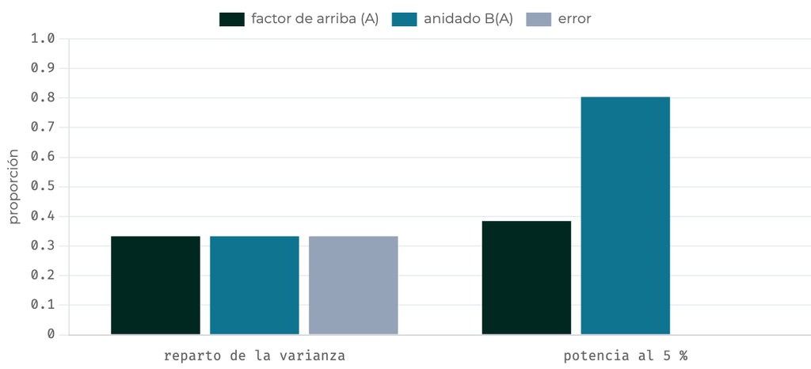

Reparto de la varianza total entre el factor de arriba, el anidado y el error, y potencia de las dos pruebas F

Dato · cálculo del curso

\(a = 3\), \(b = 4\), \(n = 3\), los dos factores aleatorios y \(\sigma^2_\tau = \sigma^2_\beta = \sigma^2 = 1\). Potencia al 5 %:

- Factor de arriba: **0.3847**
- Factor anidado: **0.8041**

**Interpretación.** Las dos pruebas tienen la misma razón de esperanzas, \(16/4 = 4/1 = 4\): la diferencia la ponen los gl, 2 y 9 arriba frente a 9 y 24 en medio.

Fuente: precálculo del capítulo, potencia exacta con la \(F\) central escalada · módulo 9.6

Capítulo 9 · Diseños anidadosDiseño de Experimentos · UnBosque10 / 39

Pregunta para la clase

## ¿Cuánto vale \(\hat\sigma^2_\beta\)?

Un anidado de dos etapas con **2** observaciones por celda: \(MS_{B(A)} = 352.2083\) y \(MS_E = 84.5\). Estima el componente por el método del ANOVA.

133.854167

\((352.2083 - 84.5)/2 = 267.7083/2 = 133.8542\). Se divide entre \(n = 2\), el coeficiente de \(\sigma^2_\beta\) en la esperanza.

Fuente: Montgomery (2017), problema 14.2 · módulo 9.6

Capítulo 9 · Diseños anidadosDiseño de Experimentos · UnBosque11 / 39

Universidad El Bosque

Diseño de Experimentos

Capítulo 9 · Diseños anidados

Estimar los componentes de varianza

Intervalos para los componentes

Diagnóstico del modelo anidado

El anidado de m etapas

Anidado y cruzado a la vez

Ciencia de datos: la fuga por agrupación

Cierre y práctica

02

## Intervalos para los componentes

Un componente estimado sin su intervalo no dice gran cosa.

Leer en el material: 9.7 Intervalos para los componentes

12 / 39

Intervalos para los componentes

## El error estándar de un componente sale de \(\operatorname{Var}(MS) = 2\,[E(MS)]^2/f\)

$$\hat{\boldsymbol\theta} = \mathbf{A}\,\mathbf{MS} \;\Longrightarrow\; \operatorname{Var}(\hat{\boldsymbol\theta}) = \mathbf{A}\,\mathbf{D}\,\mathbf{A}', \quad \mathbf{D} = \operatorname{diag}\!\left(\frac{2\,MS_i^2}{f_i}\right)$$

Dato · ejemplo 14.1

- \(\operatorname{Var}(\hat\sigma^2) = 0.580311\), \(\operatorname{Var}(\hat\sigma^2_\beta) = 1.554600\), covarianza \(-0.193437\): los de JMP en la Tabla 14.7, dígito a dígito
- Errores estándar: \(\sqrt{0.580311} = 0.7618\) y \(\sqrt{1.554600} = 1.2468\)

**Interpretación.** La covarianza es negativa: si el error sale grande, la diferencia \(MS_{B(A)} - MS_E\) sale pequeña.

Fuente: Montgomery (2017), Tabla 14.7; código R del módulo 9.7

Capítulo 9 · Diseños anidadosDiseño de Experimentos · UnBosque13 / 39

Intervalos para los componentes

## Solo \(\sigma^2\) tiene intervalo exacto; el de \(\sigma^2_\beta\) baja de cero o llega a 15.6

### Wald, para \(\sigma^2_\beta\)

\(1.709877 \pm 1.96 \times 1.246836\)  
\((-0.7339,\ 4.1537)\): baja de cero

### Exacto, para \(\sigma^2\)

\(24 \times 2.6389/39.36\) y \(/12.40\)  
\((1.6089,\ 5.1071)\): asimétrico y positivo

### Satterthwaite, para \(\sigma^2_\beta\)

\(\dfrac{(7.7685 - 2.6389)^2}{7.7685^2/9 + 2.6389^2/24} = 3.761\) gl  
\((0.5996,\ 15.5972)\): positivo y enorme

**Interpretación.** \(\sigma^2\) es la esperanza de **un solo** cuadrado medio y admite intervalo exacto; \(\sigma^2_\beta\) es una diferencia de dos, que no es \(\chi^2\) de nada.

Fuente: Montgomery (2017), ecs. 13.19, 13.22 y 13.23 y Tabla 14.7; código R del módulo 9.7

Capítulo 9 · Diseños anidadosDiseño de Experimentos · UnBosque14 / 39

Pregunta para la clase

## ¿Qué dice el extremo izquierdo del gráfico?

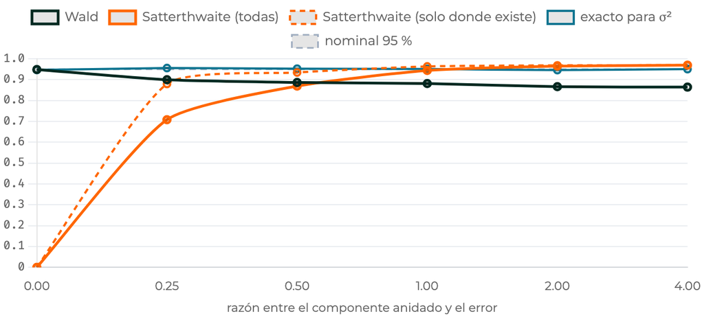

Cobertura medida de los intervalos de Wald, de Satterthwaite y exacto, frente a la razón entre el componente anidado y el error

Con el componente **exactamente en cero**: Satterthwaite cubre **0** y Wald, **0.949**.

1. Wald es preferible siempre.
2. La simulación tiene un error.
3. Hay que usar el exacto por \(\chi^2\).
4. Para el componente, en la frontera no sirve ninguno.

4

Satterthwaite es positivo por construcción: no contiene el cero nunca. Wald cubre, pero el 55.1 % de su longitud cae en varianzas negativas.

Fuente: simulación del curso, `set.seed(2026)`, 3000 réplicas por punto · módulo 9.7

Capítulo 9 · Diseños anidadosDiseño de Experimentos · UnBosque15 / 39

Universidad El Bosque

Diseño de Experimentos

Capítulo 9 · Diseños anidados

Estimar los componentes de varianza

Intervalos para los componentes

Diagnóstico del modelo anidado

El anidado de m etapas

Anidado y cruzado a la vez

Ciencia de datos: la fuga por agrupación

Cierre y práctica

03

## Diagnóstico del modelo anidado

El diagnóstico del capítulo 4, con el residuo tomado de la celda más pequeña.

Leer en el material: 9.8 Diagnóstico del modelo anidado

16 / 39

Diagnóstico del modelo anidado

## El residuo se toma de la media del lote, y en la pureza no da ninguna alarma

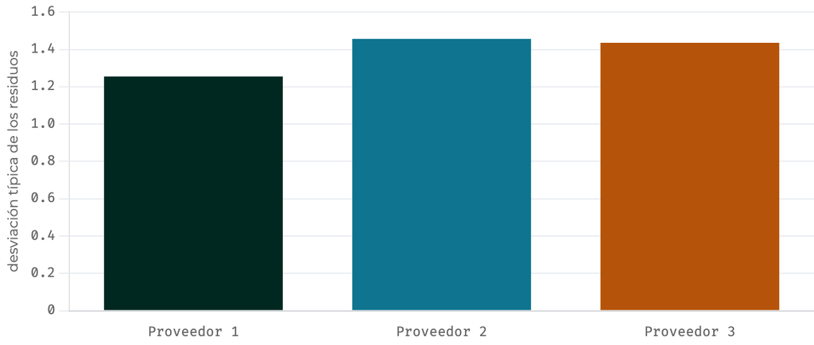

Desviación típica de los residuos del modelo anidado por proveedor

$$e_{ijk} = y_{ijk} - \bar y_{ij\cdot}$$

Dato · ejemplo 14.1

- Correlación del gráfico normal: **0.9765**
- Desviación por proveedor: 1.2553, 1.4564 y 1.4355; razón \(1.4564/1.2553 = 1.1602\)

**Interpretación.** Como suman cero dentro de cada lote, no pueden mostrar curvatura, pero sí un abanico; aquí no lo hay, y el modelo es adecuado.

Fuente: Montgomery (2017), ec. 14.9; código R del módulo 9.8

Capítulo 9 · Diseños anidadosDiseño de Experimentos · UnBosque17 / 39

Diagnóstico del modelo anidado

## REML da aquí los mismos componentes, y su \(-2\log L\) depende de la codificación

Dato · ejemplo 14.1, `lme()` de nlme

- Componentes por REML: 1.709877 y 2.638889, **los mismos** del método del ANOVA
- \(-2\log L\): 142.8440 con tratamiento, 146.4275 con Helmert y **145.0412** con suma cero, la de JMP

**Criterio del curso.** El material fija `contr.sum` y lo declara. Para comparar modelos con efectos fijos distintos sirve el \(-2\log L\) de máxima verosimilitud, no el de REML.

Fuente: Montgomery (2017), Tabla 14.7; código R del módulo 9.8

Capítulo 9 · Diseños anidadosDiseño de Experimentos · UnBosque18 / 39

Universidad El Bosque

Diseño de Experimentos

Capítulo 9 · Diseños anidados

Estimar los componentes de varianza

Intervalos para los componentes

Diagnóstico del modelo anidado

El anidado de m etapas

Anidado y cruzado a la vez

Ciencia de datos: la fuga por agrupación

Cierre y práctica

04

## El anidado de m etapas

Añadir etapas no cambia nada: es el mismo motor con un subíndice más.

Leer en el material: 9.9 El anidado de m etapas y el reparto de los gl

19 / 39

El anidado de m etapas

## Con tres etapas, el denominador es la etapa inmediatamente inferior, si es aleatoria

Dato · Montgomery (2017), problemas 14.5 y 14.6

Dureza de una aleación: **2** químicas, **3** coladas por química, **2** lingotes por colada y **2** mediciones por lingote: 24 datos.

$$y_{ijkl} = \mu + \tau_i + \beta_{j(i)} + \gamma_{k(ij)} + \varepsilon_{(ijk)l}$$

- gl: \(a - 1 = 1\), \(a(b-1) = 4\), \(ab(c-1) = 6\) y \(abc(n-1) = 12\)
- En una cadena, la esperanza de un término es su componente más las de abajo: el denominador es el **hijo inmediato**
- Si una etapa intermedia es fija, el denominador **la salta**

**Interpretación.** Nada nuevo: el lingote arrastra dos subíndices muertos y el motor es el mismo.

Fuente: Montgomery (2017), ec. 14.13 y figura 14.5 · módulo 9.9

Capítulo 9 · Diseños anidadosDiseño de Experimentos · UnBosque20 / 39

El anidado de m etapas

## Los grados de libertad se acumulan abajo: el error se lleva el 52 % y la química, uno

|  | Química | Coladas | Lingotes | Error |
| --- | --- | --- | --- | --- |
| gl | 1 | 4 | 6 | 12 |
| % de \(1 + 4 + 6 + 12 = 23\) | 4.35 | 17.39 | 26.09 | 52.17 |

Dato · cálculo del curso: otro diseño, con 10 unidades arriba

Balanceado \(10 \times 2 \times 2\): \(N = 40\), gl 9 / 10 / 20, \(20/39\) = **51.3 %** abajo. Escalonado de §14.1.4: \(N = 30\), gl 9 / 10 / 10, \(10/29\) = **34.5 %** abajo.

**Criterio del curso.** El reparto se decide **antes** de recoger los datos, y el escalonado es una alternativa: diez observaciones menos y gl casi parejos, a cambio de perder el balance.

Fuente: Montgomery (2017), problemas 14.5 y 14.6 y §14.1.4; código R del módulo 9.9

Capítulo 9 · Diseños anidadosDiseño de Experimentos · UnBosque21 / 39

Universidad El Bosque

Diseño de Experimentos

Capítulo 9 · Diseños anidados

Estimar los componentes de varianza

Intervalos para los componentes

Diagnóstico del modelo anidado

El anidado de m etapas

Anidado y cruzado a la vez

Ciencia de datos: la fuga por agrupación

Cierre y práctica

05

## Anidado y cruzado a la vez

Los diseños reales rara vez son puros.

Leer en el material: 9.10 Anidado y cruzado a la vez

22 / 39

Anidado y cruzado a la vez

## Dispositivos y disposiciones cruzados; cuatro operarios anidados en cada disposición

Dato · Montgomery (2017), ejemplo 14.2, Tabla 14.10

El tiempo de ensamble de componentes en tarjetas de circuito impreso, con dos disposiciones del puesto de trabajo. Cada operario prueba los **tres** dispositivos de sujeción, dos veces.

1Disposicióncruzada con el dispositivo: \(b = 2\)

→

2Operario dentro de la disposiciónanidado: \(c = 4\) distintos en cada una

→

3Dispositivocruzado con todo, con 2 réplicas por celda: \(3 \times 2\) por operario, \(N = 48\)

**Interpretación.** Es un factorial de dos factores con una etapa de muestreo que cuelga de uno de ellos.

Fuente: Montgomery (2017), ejemplo 14.2, Tabla 14.10 · módulo 9.10

Capítulo 9 · Diseños anidadosDiseño de Experimentos · UnBosque23 / 39

Anidado y cruzado a la vez

## El modelo lleva cinco términos, y disposición × operario no está entre ellos

$$y_{ijkl} = \mu + \tau_i + \beta_j + \gamma_{k(j)} + (\tau\beta)_{ij} + (\tau\gamma)_{ik(j)} + \varepsilon_{(ijk)l}$$

- \(\tau_i\): dispositivo, fijo; \(\beta_j\): disposición, fija
- \(\gamma_{k(j)}\): operario **dentro de** la disposición, aleatorio; la \(j\) va muerta
- \((\tau\beta)_{ij}\) y \((\tau\gamma)_{ik(j)}\): las dos interacciones que sí existen

**Interpretación.** Disposición × operario no se puede ni escribir: ningún operario trabaja en las dos disposiciones.

Fuente: Montgomery (2017), ejemplo 14.2 · módulo 9.10

Capítulo 9 · Diseños anidadosDiseño de Experimentos · UnBosque24 / 39

Anidado y cruzado a la vez

## La tabla: el operario siempre va pegado a su disposición

La tabla del anidado-factorial (ejemplo 14.2)

```
ens_aov <- anova(aov(y ~ A * B + B:C + A:B:C,
                     data = ens))
round(ens_aov[, 1:3], 4)
#>           Df Sum Sq Mean Sq
#> A          2 82.792  41.396
#> B          1  4.083   4.083
#> A:B        2 19.042   9.521
#> B:C        6 71.917  11.986
#> A:B:C     12 65.833   5.486
#> Residuals 24 56.000   2.333
```

- \(A\): dispositivo; \(B\): disposición; \(C\): operario
- `B:C` y `A:B:C`: «operario 1» no existe fuera de su disposición
- \(2 + 1 + 2 + 6 + 12 + 24 = 47 = N - 1\)

**Interpretación.** Las dos filas resaltadas son lo que la etapa anidada añade a un factorial de dos factores.

Fuente: Montgomery (2017), ejemplo 14.2, Tablas 14.12 y 14.13; código R del módulo 9.10

Capítulo 9 · Diseños anidadosDiseño de Experimentos · UnBosque25 / 39

Anidado y cruzado a la vez

## Quitando el operario queda el factorial del capítulo 7, con las mismas sumas de cuadrados

Dato · ejemplo 14.2

`anova(aov(y ~ A * B))` da, para dispositivo, disposición y su interacción, **82.7917**, **4.0833** y **19.0417**: las tres filas de la tabla anterior.

**Interpretación.** Un anidado-factorial no es un diseño nuevo: es el factorial de siempre con una etapa de muestreo colgando de uno de sus factores.

Fuente: Montgomery (2017), ejemplo 14.2; código R del módulo 9.10

Capítulo 9 · Diseños anidadosDiseño de Experimentos · UnBosque26 / 39

Anidado y cruzado a la vez

## De las cinco esperanzas cambian dos entre los modelos, pero solo un denominador

| Término | Restringido | No restringido |
| --- | --- | --- |
| \(A\) dispositivo | \(\sigma^2 + 16Q[A] + 2\sigma^2_{AC}\) | igual |
| \(B\) disposición | \(\sigma^2 + 24Q[B] + 6\sigma^2_C\) | \(\ldots + 2\sigma^2_{AC}\) |
| \(C\) operario | \(\sigma^2 + 6\sigma^2_C\) | \(\sigma^2 + 6\sigma^2_C + \mathbf{2\sigma^2_{AC}}\) |
| \(AB\) | \(\sigma^2 + 8Q[AB] + 2\sigma^2_{AC}\) | igual |
| \(AC\) | \(\sigma^2 + 2\sigma^2_{AC}\) | igual |

Operarios: contra el **error** en el restringido; contra la **interacción \(AC\)** en el no restringido.

**Interpretación.** La de las disposiciones gana \(2\sigma^2_{AC}\) sin cambiar de denominador, que es el de los operarios en los dos. La que decide es la de los operarios.

Fuente: algoritmo de §13.4 del módulo 9.10; Montgomery (2017), Tablas 14.11, 14.13 y 14.14

Capítulo 9 · Diseños anidadosDiseño de Experimentos · UnBosque27 / 39

Anidado y cruzado a la vez

## El restringido pide que la interacción fijo × aleatorio sume cero sobre el factor fijo

**Restringido:** \(\sum_i (\tau\gamma)_{ik(j)} = 0\) para cada \((j, k)\). La restricción crea una covarianza negativa que cancela \(\sigma^2_{AC}\) en \(E(MS_C)\)

**No restringido:** todos los términos aleatorios, independientes. La interacción sí entra en la esperanza del operario

En un anidado **puro** no hay interacciones: los dos modelos son siempre el mismo

**Interpretación.** La diferencia aparece cuando hay una interacción fijo × aleatorio, y un anidado puro no tiene ninguna.

Fuente: Montgomery (2017), §13.3 (p. 597) y §13.4, regla 6 · módulo 9.10

Capítulo 9 · Diseños anidadosDiseño de Experimentos · UnBosque28 / 39

Anidado y cruzado a la vez

## Mismos datos, dos veredictos: los operarios, significativos al 1 % o no

Dato · ejemplo 14.2, misma tabla de sumas de cuadrados

- Restringido, contra el error: \(F = 11.986111/2.333333 = 5.1369\), \(p = 0.0016\)
- No restringido, contra \(AC\): \(F = 11.9861/5.4861 = 2.1848\), \(p = 0.1174\)

**Interpretación.** Con los mismos datos, los operarios son significativos al 1 % en un modelo y no lo son en el otro.

Fuente: Montgomery (2017), Tablas 14.13 y 14.14; código R del módulo 9.10

Capítulo 9 · Diseños anidadosDiseño de Experimentos · UnBosque29 / 39

Pregunta para la clase

## Sobre los dos modelos mixtos, ¿cuáles son correctas?

1. Todo depende de si la interacción cruzado × anidado entra en la esperanza del factor anidado.
2. En un anidado puro los dos modelos coinciden siempre, y hay una razón estructural.
3. La elección entre los dos hay que declararla antes de mirar el resultado.
4. El no restringido siempre da valores \(p\) mayores, porque su denominador es más grande.
5. Como las sumas de cuadrados son idénticas, la diferencia es cosmética.

1, 2 y 3

La 4 no: el cuadrado medio de la interacción puede ser mayor o menor que el error según los datos. La 5 no: también cambia el componente, de 1.6088 a 1.0833; \(1.0833/1.6088 = 0.673\), un 33 % menos.

Fuente: Montgomery (2017), ejemplo 14.2 · módulo 9.10

Capítulo 9 · Diseños anidadosDiseño de Experimentos · UnBosque30 / 39

Anidado y cruzado a la vez

## Ojo en las pp. 631–632: el libro cuenta al revés los denominadores de los operarios

Dato · errata E5 de Montgomery (2017), pp. 631–632

El párrafo que presenta la Tabla 14.14 da la interacción dispositivo × operario (12 gl) en el restringido y la disposición × dispositivo (2 gl) en el no restringido.

- Las columnas «Error term» de las Tablas 14.13 y 14.14 dicen otra cosa: el **error** (24 gl, \(F = 5.14\)) y la **interacción dispositivo × operario** (12 gl, \(F = 2.18\))
- Disposición × dispositivo no puede ser denominador de los operarios: su esperanza lleva \(8Q[AB]\)

**Criterio del curso.** Cuando el texto y la tabla del libro discrepan, se recalcula: aquí mandan las tablas.

Fuente: Montgomery (2017), pp. 631–632, Tablas 14.13 y 14.14 · módulo 9.10

Capítulo 9 · Diseños anidadosDiseño de Experimentos · UnBosque31 / 39

Universidad El Bosque

Diseño de Experimentos

Capítulo 9 · Diseños anidados

Estimar los componentes de varianza

Intervalos para los componentes

Diagnóstico del modelo anidado

El anidado de m etapas

Anidado y cruzado a la vez

Ciencia de datos: la fuga por agrupación

Cierre y práctica

06

## Ciencia de datos: la fuga por agrupación

Un conjunto con varias medidas por paciente, sensor o tienda es un anidado aunque nadie lo haya diseñado.

Leer en el material: 9.11 Ciencia de datos: la fuga por agrupación

32 / 39

Ciencia de datos: la fuga por agrupación

## Con una correlación intraclase de 0.8311, 180 filas valen lo que 35

$$m_{\text{ef}} = \frac{m}{1 + (m-1)\rho}$$

Dato · simulación del curso, semilla 2026

Treinta grupos con seis medidas cada uno; \(\hat\rho = 0.8311\) por el método de la sesión.

- \(1 + 5 \times 0.831074 = 5.1554\) y \(6/5.1554 = 1.16\) medidas efectivas por grupo
- \(180/5.1554 = 34.9\) observaciones efectivas

**Interpretación.** Quien crea tener 180 datos independientes subestima unas cinco veces la varianza de la media, y su intervalo sale \(\sqrt{5.1554} = 2.27\) veces más estrecho.

Fuente: simulación del curso, `set.seed(2026)`, 30 grupos × 6 medidas · módulo 9.11

Capítulo 9 · Diseños anidadosDiseño de Experimentos · UnBosque33 / 39

Pregunta para la clase

## Filas al azar: 1.1203; pacientes enteros: 1.2454. ¿Cuál es la lectura?

Un equipo entrena un modelo sobre 180 filas: 6 medidas de cada uno de 30 pacientes. Validación cruzada de 5 pliegues.

1. La primera es optimista: cada fila de prueba tiene a su paciente en el entrenamiento.
2. La segunda es pesimista, porque entrena con menos datos.
3. Las dos son válidas: se informa la media.
4. Con 10 pliegues se corregiría la diferencia.

1

El modelo aprovecha una pista del paciente, no del predictor, que no existe cuando llega un paciente nuevo. Es tomar las submuestras por réplicas, visto desde la predicción: \(1.1203/1.2454 = 0.90\), un 10 % de optimismo.

Fuente: simulación del curso, `set.seed(2026)`, k vecinos con \(k = 3\) · módulo 9.11

Capítulo 9 · Diseños anidadosDiseño de Experimentos · UnBosque34 / 39

Universidad El Bosque

Diseño de Experimentos

Capítulo 9 · Diseños anidados

Estimar los componentes de varianza

Intervalos para los componentes

Diagnóstico del modelo anidado

El anidado de m etapas

Anidado y cruzado a la vez

Ciencia de datos: la fuga por agrupación

Cierre y práctica

07

## Cierre y práctica

Leer en el material: 9.12 Resumen, autoevaluación y lecturas

35 / 39

Idea clave · Criterio del curso

## La estructura de los datos manda sobre el algoritmo

Partir filas con datos agrupados es el mismo error que probar el factor de arriba contra el error: una cifra optimista que no se cumple en producción.

Capítulo 9 · Diseños anidadosDiseño de Experimentos · UnBosque36 / 39

Cierre y práctica

## Lo que se llevan hoy

- Un componente se estima igualando cuadrados medios a esperanzas; puede salir negativo, y se informa
- Para el componente, ningún intervalo funciona en la frontera: Satterthwaite no cubre el cero y Wald se va a varianzas negativas
- Con más etapas, el denominador es la etapa aleatoria inmediatamente inferior, y los gl se acumulan abajo
- Con factores cruzados y anidados, restringido y no restringido pueden dar veredictos opuestos: se declara antes
- Datos agrupados son un anidado: se valida partiendo grupos

Javier Mauricio Sierra

Capítulo 9 · Diseños anidadosDiseño de Experimentos · UnBosque37 / 39

Cierre y práctica

## Práctica en R: los ejercicios guiados

### En clase · EG-36 (a) a (d)

Máquinas, potencias y estaciones: qué está anidado, por qué no hay interacción máquina × estación y qué denominadores cambian con la potencia aleatoria. Datos, en la diapositiva siguiente.

### Si sobra tiempo · EG-33 (c) y (d)

Propelente: sus componentes de varianza y el reparto si los procesos también son aleatorios. Si no, a casa.

### En casa · EG-35

Aleación: la tabla (b), las esperanzas (c) y, con el algoritmo, el anidado puro de hoy (d).

### En casa · EG-34 (c)

Husillos: los componentes de varianza que quedaron de la sesión 1.

**Criterio del curso.** Primero los términos con sus subíndices vivos y muertos; después, el algoritmo.

Fuente: Montgomery (2017), problemas 14.1, 14.3, 14.5–14.6 y 14.13–14.14 · módulo 9.12

Capítulo 9 · Diseños anidadosDiseño de Experimentos · UnBosque38 / 39

Cierre y práctica

## Los datos del EG-36: tres máquinas, dos potencias y tres estaciones por máquina

| Potencia 1 | Máquina 1 | Máquina 2 | Máquina 3 |
| --- | --- | --- | --- |
| Estación 1 | 34.1 · 30.3 · 31.6 | 31.1 · 33.5 · 34.0 | 32.9 · 33.0 · 33.1 |
| Estación 2 | 33.7 · 34.9 · 35.0 | 33.1 · 34.7 · 33.9 | 33.8 · 33.4 · 32.8 |
| Estación 3 | 36.2 · 36.8 · 37.1 | 32.8 · 35.1 · 34.3 | 33.6 · 32.8 · 31.7 |

| Potencia 2 | Máquina 1 | Máquina 2 | Máquina 3 |
| --- | --- | --- | --- |
| Estación 1 | 24.3 · 26.3 · 27.1 | 24.1 · 25.0 · 26.3 | 24.2 · 26.1 · 25.3 |
| Estación 2 | 28.1 · 29.3 · 28.6 | 24.1 · 25.1 · 27.9 | 23.2 · 27.4 · 28.0 |
| Estación 3 | 25.7 · 26.1 · 24.9 | 26.0 · 27.1 · 23.9 | 24.7 · 22.0 · 24.8 |

**Dato.** 54 observaciones: 2 potencias × 3 máquinas × 3 estaciones × 3 repeticiones.

Fuente: Montgomery (2017), problema 14.13, Tabla P14.1, p. 652 · EG-36 del módulo 9.12

Capítulo 9 · Diseños anidadosDiseño de Experimentos · UnBosque39 / 39

### Atajos del teclado

[output not shown]

·

00:00

A continuación

Notas